# R Notebook

The first step involves setting the working directory and importing the required libraries

```r
#install.packages("ff")
LibImport <- function(path)
{
  setwd(path)
  #library("ff")
  library(ggplot2)
  library(caret)
  library(rpart)
  library(randomForest)
  load.libraries <- c('data.table', 'testthat', 'gridExtra', 'corrplot', 'GGally', 'ggplot2', 'e1071', 'dplyr','Hmisc')
  install.lib <- load.libraries[!load.libraries %in% installed.packages()]
  for(libs in install.lib) install.packages(libs, dependences = TRUE)
  sapply(load.libraries, require, character = TRUE)
}
```

Calling the Library Import Function: -

```r
path.var = "C:/Users/LEON/Desktop/Ds Udemy/House_Pred"
LibImport(path.var)
```

```
## data.table   testthat  gridExtra   corrplot     GGally    ggplot2
##       TRUE       TRUE       TRUE       TRUE       TRUE       TRUE
##      e1071      dplyr      Hmisc
##       TRUE       TRUE       TRUE
```

Creating a function to count features with missing values and to plot a visual of them.

```r
PlotMissing <- function(full.dat)
{
    num_na <- sort(colSums(is.na(full.dat)), decreasing = TRUE)
    num_na <- num_na[num_na>0]

    ggplot()+ geom_bar(aes(x=reorder(names(num_na),num_na), y= num_na),stat = 'identity')+xlab("Variables with Missing Values")+ylab("Number of missing values")+coord_flip()
}
```

```r
test_data <- read.csv("test.csv",stringsAsFactors = FALSE)
train_data <- read.csv("train.csv",stringsAsFactors = FALSE)
summary(test_data)
```

```
##        Id         MSSubClass       MSZoning          LotFrontage
##  Min.   :1461   Min.   : 20.00   Length:1459        Min.   : 21.00
##  1st Qu.:1826   1st Qu.: 20.00   Class :character   1st Qu.: 58.00
##  Median :2190   Median : 50.00   Mode  :character   Median : 67.00
##  Mean   :2190   Mean   : 57.38                      Mean   : 68.58
##  3rd Qu.:2554   3rd Qu.: 70.00                      3rd Qu.: 80.00
##  Max.   :2919   Max.   :190.00                      Max.   :200.00
##                                                     NA's   :227
##     LotArea         Street             Alley             LotShape
##  Min.   : 1470   Length:1459        Length:1459        Length:1459
##  1st Qu.: 7391   Class :character   Class :character   Class :character
##  Median : 9399   Mode  :character   Mode  :character   Mode  :character
##  Mean   : 9819
##  3rd Qu.:11518
##  Max.   :56600
##
##  LandContour         Utilities          LotConfig
##  Length:1459        Length:1459        Length:1459
##  Class :character   Class :character   Class :character
##  Mode  :character   Mode  :character   Mode  :character
##
##
##
##
##   LandSlope         Neighborhood        Condition1
##  Length:1459        Length:1459        Length:1459
##  Class :character   Class :character   Class :character
##  Mode  :character   Mode  :character   Mode  :character
##
##
##
##
##   Condition2          BldgType          HouseStyle         OverallQual
##  Length:1459        Length:1459        Length:1459        Min.   : 1.000
##  Class :character   Class :character   Class :character   1st Qu.: 5.000
##  Mode  :character   Mode  :character   Mode  :character   Median : 6.000
##                                                           Mean   : 6.079
##                                                           3rd Qu.: 7.000
##                                                           Max.   :10.000
##
```

[output cut: 121 more lines]

```
##  Min.   :    0.00   Min.   : 1.000   Min.   :2006   Length:1459
##  1st Qu.:    0.00   1st Qu.: 4.000   1st Qu.:2007   Class :character
##  Median :    0.00   Median : 6.000   Median :2008   Mode  :character
##  Mean   :   58.17   Mean   : 6.104   Mean   :2008
##  3rd Qu.:    0.00   3rd Qu.: 8.000   3rd Qu.:2009
##  Max.   :17000.00   Max.   :12.000   Max.   :2010
##
##  SaleCondition
##  Length:1459
##  Class :character
##  Mode  :character
##
##
##
##
```

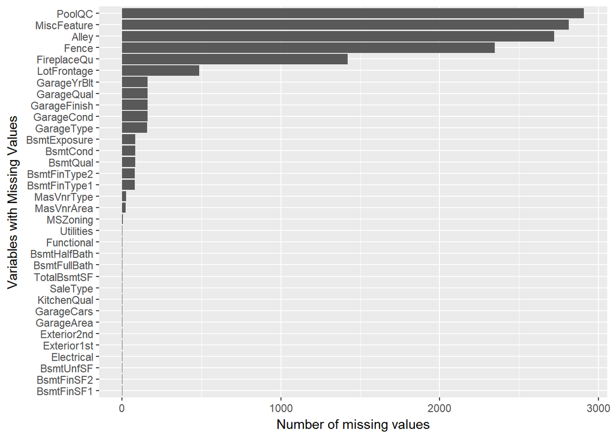

```r
target_variable <- train_data$SalePrice

full <- rbind(train_data[,1:80],test_data)

PlotMissing(full)
```

The next step is to explore these features and determine the percentage of missing values for each of them to decide whether to drop them or impute the missing values.

```r
summary(full$PoolQC)
```

```
##    Length     Class      Mode
##      2919 character character
```

```r
summary(full$MiscFeature)
```

```
##    Length     Class      Mode
##      2919 character character
```

```r
summary(full$Alley)
```

```
##    Length     Class      Mode
##      2919 character character
```

```r
summary(full$Fence)
```

```
##    Length     Class      Mode
##      2919 character character
```

```r
summary(full$FireplaceQu)
```

```
##    Length     Class      Mode
##      2919 character character
```

```r
summary(full$LotFrontage)
```

```
##    Min. 1st Qu.  Median    Mean 3rd Qu.    Max.    NA's
##   21.00   59.00   68.00   69.31   80.00  313.00     486
```

```r
feat_excluded <- c("PoolQC","MiscFeature","Alley","Fence","FireplaceQu")
```

```r
ExtractColTypes <- function(train_data)
{
  cat_var <- names(train_data)[which(sapply(train_data, is.factor))]
  cat_car <- c(cat_var, 'BedroomAbvGr', 'HalfBath', ' KitchenAbvGr','BsmtFullBath', 'BsmtHalfBath', 'MSSubClass')
  numeric_var <- names(train_data)[which(sapply(train_data, is.numeric))]

  return(list(v1=cat_var,v2=cat_car,v3=numeric_var))
  }

list_types <- ExtractColTypes(train_data)

cat_var <- list_types$v1
cat_car <- list_types$v2
numeric_var <- list_types$v3
```

The next step involves plotting a correlation matrix for the numeric variables. We create a function for reusability.

```r
PlotCorMat <- function(df,num_var)
{
cor_matx <- round(cor(na.omit(df[,names(df)%in%num_var])),2)

corrplot(corr = cor_matx, method = "circle",type='lower',title = "Correlation plot of Numeric Variables",addCoefasPercent=TRUE,order = "FPC",tl.cex = 0.6,tl.srt = 45,tl.col ='black')
}
```

Creating the Correlation Map for the entire dataset excluding the Target Variable.

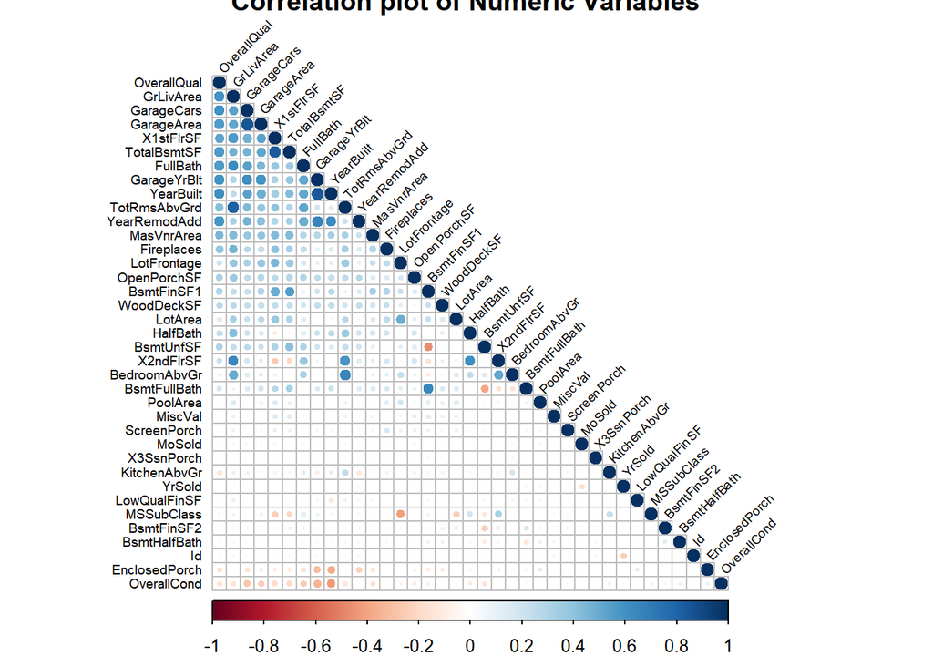

```r
PlotCorMat(full,numeric_var)
```

Calculating the percentage of missing values for each feature having NA’s

```r
list_na_vars = c('PoolQC','MiscFeature','Alley','Fence','FireplaceQu','LotFrontage','GarageYrBlt','GarageQual','GarageFinish','GarageCond','GarageType')
na_values <- as.list(NULL)
na_values <- colSums(is.na(full[,list_na_vars]))
na_percs <- lapply(na_values, FUN = function(x){((x/2919)*100)})
df.na_percs <- as.data.frame(na_percs)
na_values <- as.data.frame(na_values)
na_values
```

```
##              na_values
## PoolQC            2909
## MiscFeature       2814
## Alley             2721
## Fence             2348
## FireplaceQu       1420
## LotFrontage        486
## GarageYrBlt        159
## GarageQual         159
## GarageFinish       159
## GarageCond         159
## GarageType         157
```

```r
df.na_percs
```

```
##     PoolQC MiscFeature    Alley    Fence FireplaceQu LotFrontage
## 1 99.65742    96.40288 93.21686 80.43851     48.6468    16.64954
##   GarageYrBlt GarageQual GarageFinish GarageCond GarageType
## 1    5.447071   5.447071     5.447071   5.447071   5.378554
```

Imputing the missing values for the missing values or deciding to drop or keep features.

```r
summary(full$LotFrontage)
```

```
##    Min. 1st Qu.  Median    Mean 3rd Qu.    Max.    NA's
##   21.00   59.00   68.00   69.31   80.00  313.00     486
```

```r
#full$LotFrontage[which(is.na(full$LotFrontage))] <- 68
summary(full$LotFrontage)
```

```
##    Min. 1st Qu.  Median    Mean 3rd Qu.    Max.    NA's
##   21.00   59.00   68.00   69.31   80.00  313.00     486
```

```r
summary(full$FireplaceQu)
```

```
##    Length     Class      Mode
##      2919 character character
```

```r
summary(full$Fireplaces)
```

```
##    Min. 1st Qu.  Median    Mean 3rd Qu.    Max.
##  0.0000  0.0000  1.0000  0.5971  1.0000  4.0000
```

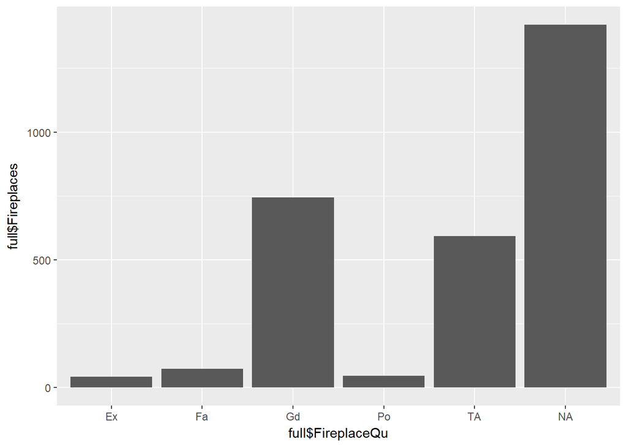

```r
ggplot(full, aes(x=full$FireplaceQu, y=full$Fireplaces)) + stat_summary(fun.y ="length", geom="bar")
```

```r
summary(full$GarageYrBlt)
```

```
##    Min. 1st Qu.  Median    Mean 3rd Qu.    Max.    NA's
##    1895    1960    1979    1978    2002    2207     159
```

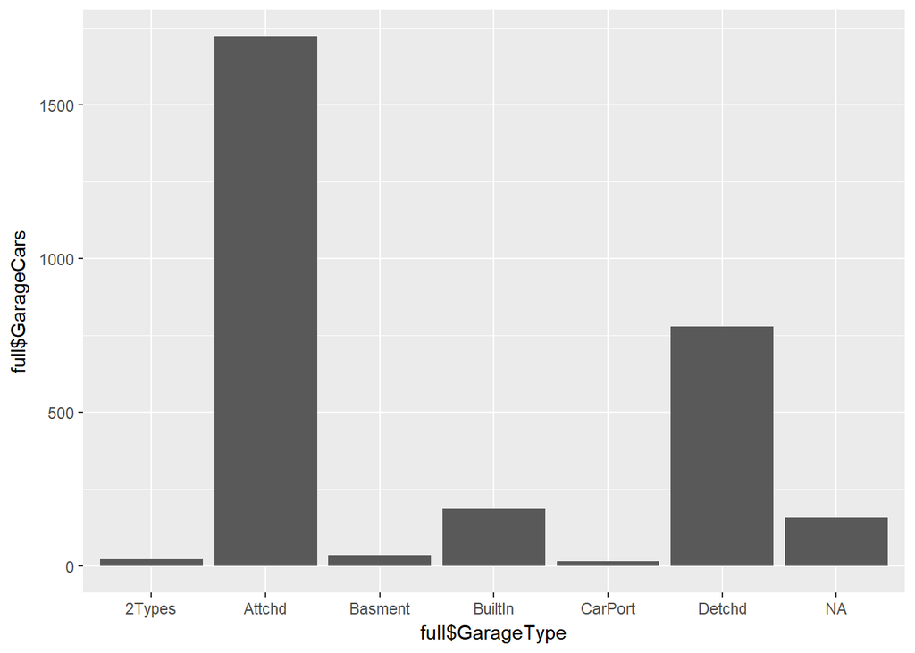

```r
ggplot(full, aes(x=full$GarageType, y=full$GarageCars)) + stat_summary(fun.y ="length", geom="bar")
```

```r
full$PoolQC[is.na(full$PoolQC)] <- 'None'

library(Amelia)
library(mice)
imp.df <- full
imp.LotFrontage <- mice(imp.df, m=1, method='cart', printFlag=FALSE)

sub.df <- imp.LotFrontage$imp$LotFrontage
sub.df$Id <- rownames(sub.df)

i <-0
fr <- length(sub.df$`1`)
for(i in 1:fr)
{
    full$LotFrontage[full$Id == sub.df$Id[i]] <- sub.df$`1`[i]
}

summary(full$LotFrontage)
```

```
##    Min. 1st Qu.  Median    Mean 3rd Qu.    Max.
##   21.00   60.00   70.00   70.09   80.00  313.00
```

```r
length(full$LotFrontage)
```

```
## [1] 2919
```

```r
full$GarageYrBlt[is.na(full$GarageYrBlt)] <- 3000
full$GarageQual[is.na(full$GarageQual)] <- 'None'
full$GarageFinish[is.na(full$GarageFinish)] <- 'None'
full$FireplaceQu[is.na(full$FireplaceQu)] <- 'None'
full$BsmtFinType2[is.na(full$BsmtFinType2)] <- 'None'
full$BsmtExposure[is.na(full$BsmtExposure)] <- 'None'
full$BsmtQual[is.na(full$BsmtQual)] <- 'None'
full$BsmtFinType1[is.na(full$BsmtFinType1)] <- 'None'
full$BsmtCond[is.na(full$BsmtCond)] <- 'None'
full$MasVnrType[is.na(full$MasVnrType)] <- 'None'
full$MasVnrArea[is.na(full$MasVnrArea)] <- 0.0
full$MSZoning[is.na(full$MSZoning)] <- 'RL'
full$Electrical[is.na(full$Electrical)] <- 'SBrkr'
full$Utilities[is.na(full$Utilities)] <- 'AllPub'
full$Functional[is.na(full$Functional)] <- 'Typ'
full$BsmtHalfBath[is.na(full$BsmtHalfBath)] <- 0
full$BsmtFullBath[is.na(full$BsmtFullBath)] <- 0
full$TotalBsmtSF[is.na(full$TotalBsmtSF)] <- 1050
full$SaleType[is.na(full$SaleType)] <- 'WD'
full$KitchenQual[is.na(full$KitchenQual)] <- 'None'
full$GarageCars[is.na(full$GarageCars)] <- 0
full$GarageArea[is.na(full$GarageArea)] <- 473
full$Exterior2nd[is.na(full$Exterior2nd)] <- 'VinylSd'
full$Exterior1st[is.na(full$Exterior1st)] <- 'VinylSd'
full$BsmtUnfSF[is.na(full$BsmtUnfSF)] <- 560
full$BsmtFinSF2[is.na(full$BsmtFinSF2)] <- 49.58
full$BsmtFinSF1[is.na(full$BsmtFinSF1)] <- 441.4
```

Plotting correations for the training dataset features against the target variable

```r
cor_tr <- cbind(train_data[,names(train_data)%in%numeric_var],target_variable)

train_cor_mat <- round(cor(na.omit(cor_tr)),2)
train_cor_mat1 <- rcorr(as.matrix(cor_tr))

flattenCorrMatrix <- function(cormat, pmat) {
  ut <- upper.tri(cormat)
  data.frame(
    row = rownames(cormat)[row(cormat)[ut]],
    column = rownames(cormat)[col(cormat)[ut]],
    cor  =(cormat)[ut],
    p = pmat[ut]
  )
}

flat_cor_mat <- flattenCorrMatrix(train_cor_mat1$r, train_cor_mat1$P)
flat_cor_mat <- filter(flat_cor_mat,flat_cor_mat$cor>0.7)
```

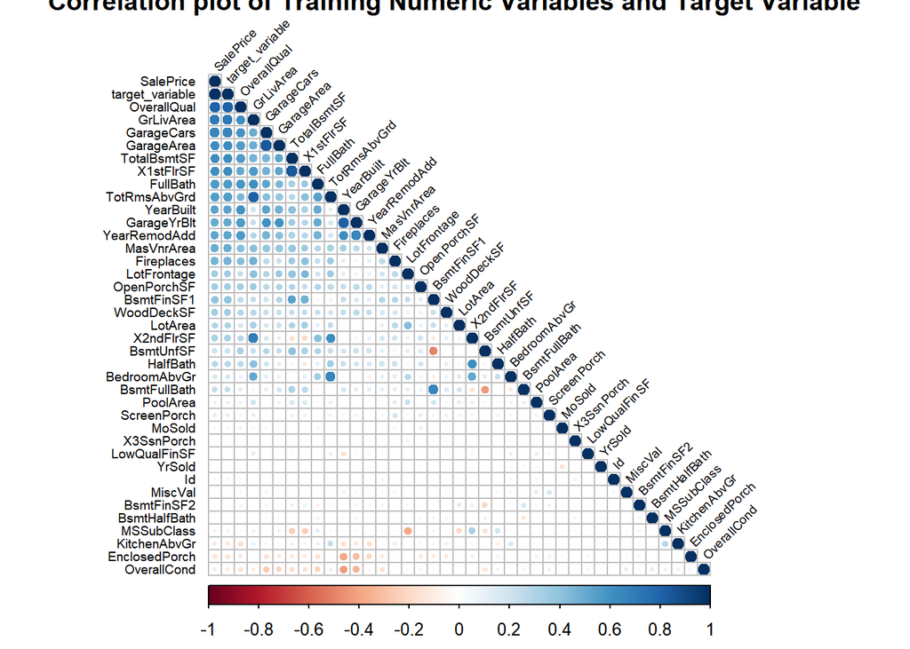

```r
corrplot(corr = train_cor_mat, method = "circle",type = 'lower',order = 'FPC',title = "Correlation plot of Training Numeric Variables and Target Variable",tl.col = "black",tl.cex = 0.6,tl.offset=0.5 ,tl.srt = 45,diag=TRUE)
```

```r
flat_cor_mat
```

```
##           row          column       cor p
## 1 TotalBsmtSF       X1stFlrSF 0.8195300 0
## 2   GrLivArea    TotRmsAbvGrd 0.8254894 0
## 3   YearBuilt     GarageYrBlt 0.8256675 0
## 4  GarageCars      GarageArea 0.8824754 0
## 5 OverallQual       SalePrice 0.7909816 0
## 6   GrLivArea       SalePrice 0.7086245 0
## 7 OverallQual target_variable 0.7909816 0
## 8   GrLivArea target_variable 0.7086245 0
## 9   SalePrice target_variable 1.0000000 0
```

Importing Additional Libraries

```r
library(Amelia)
library(mice)
library(ggplot2)
library(lattice)
```

Deciding on which features to drop

```r
exclude <- c('PoolQC', 'MiscFeature', 'Alley', 'Fence', 'GarageCond', 'GarageType')
include <- setdiff(names(full), exclude)
```

Fitting the data to a Random Forest Model to serve as a Benchmark

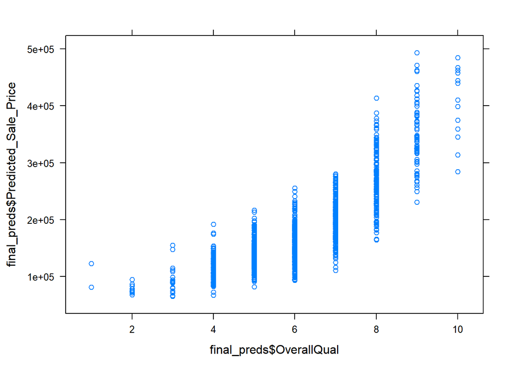

```r
#Identifying which feautures are char type to convert them to factors for th model
to_conv <- names(full)[which(sapply(full, is.character))]
to_not_conv <- names(full)[which(sapply(full, is.integer))]
full <- full %>% mutate_if(is.character, as.factor)

#Splitting the data back into training and test sets
train_new <- data.frame(cbind(full[1:1460,include], target_variable), stringsAsFactors = TRUE)
test_new <- data.frame(full[1461:2919, include], stringsAsFactors = TRUE)

#Fitting the Model to the Data
tree_model <- randomForest(formula = train_new$target_variable ~ . , data = train_new)

#Generating predictions using the fitted Model
pred_values <- predict(tree_model, test_new, type = 'response')

#Combining the final predictions into a a dataframe along witht he top correlated features
final_preds <- data.frame(cbind(test_new$Id, test_new$OverallQual, test_new$GarageCars, test_new$GrLivArea, pred_values))
colnames(final_preds) <- c('House Id','OverallQual','GarageCars','GrLivArea','Predicted_Sale_Price')

#Plotting the variance of the Sale_Price predictions with the top correlated features
xyplot(x = final_preds$Predicted_Sale_Price ~ final_preds$OverallQual, data = final_preds)
```

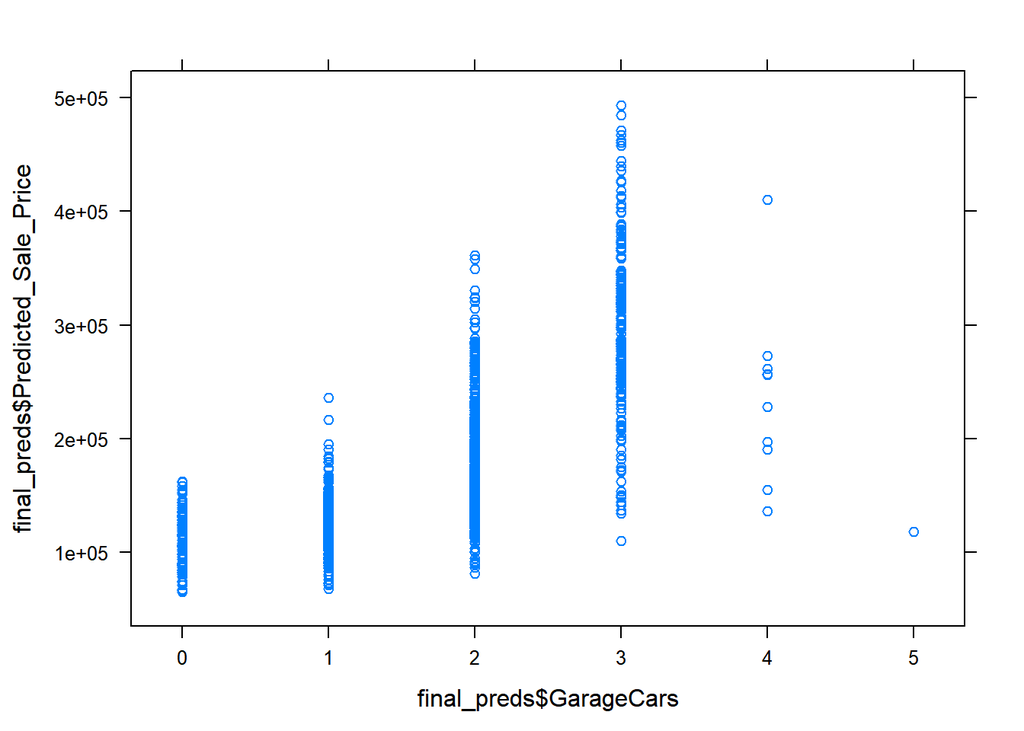

```r
xyplot(x = final_preds$Predicted_Sale_Price ~ final_preds$GarageCars, data = final_preds)
```

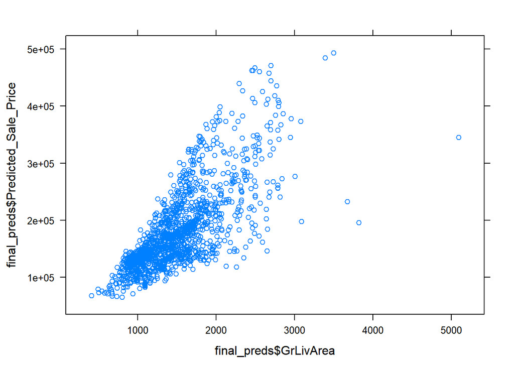

```r
xyplot(x = final_preds$Predicted_Sale_Price ~ final_preds$GrLivArea, data = final_preds)
```

Writing the results to a final submission csv file

```r
setwd("C:/Users/LEON/Desktop/Ds Udemy/House_Pred")
final_submission <- data.frame(cbind(final_preds$`House Id`, final_preds$Predicted_Sale_Price))
colnames(final_submission) <- c('Id','SalePrice')
write.csv(final_submission , file = 'bvikram_submission.csv', row.names = FALSE)
```